# Task 1: Introduction

Welcome to Basic Image Classification with TensorFlow.

This graph describes the problem that we are trying to solve visually. We want to create and train a model that takes an image of a hand written digit as input and predicts the class of that digit, that is, it predicts the digit or it predicts the class of the input image.

[figure not shown]

### Import TensorFlow

```python
import tensorflow as tf

#tf.logging.set_verbosity(tf.logging.ERROR)
print('Using TensorFlow version', tf.__version__)
```

```
Using TensorFlow version 2.10.0
```

# Task 2: The Dataset

### Import MNIST

```python
from tensorflow.keras.datasets import mnist
(x_train, y_train), (x_test,y_test)= mnist.load_data()
```

### Shapes of Imported Arrays

```python
print('A',x_train.shape)
```

```
A (60000, 28, 28)
```

### Plot an Image Example

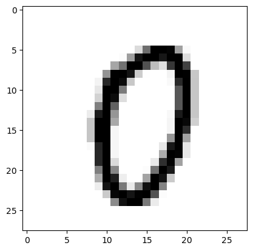

```python
from matplotlib import pyplot as plt
%matplotlib inline
plt.imshow(x_train[1000],cmap='binary')
plt.show()
```

### Display Labels

```python
y_train[1000]
```

```
0
```

```python
print(set(y_train))
```

```
{0, 1, 2, 3, 4, 5, 6, 7, 8, 9}
```

# Task 3: One Hot Encoding

After this encoding, every label will be converted to a list with 10 elements and the element at index to the corresponding class will be set to 1, rest will be set to 0:

| original label | one-hot encoded label |
| --- | --- |
| 5 | [0, 0, 0, 0, 0, 1, 0, 0, 0, 0] |
| 7 | [0, 0, 0, 0, 0, 0, 0, 1, 0, 0] |
| 1 | [0, 1, 0, 0, 0, 0, 0, 0, 0, 0] |

### Encoding Labels

```python
from tensorflow.keras.utils import to_categorical
from tensorflow.keras.datasets import mnist

# Load data
(x_train, y_train), (x_test, y_test) = mnist.load_data()

# Convert labels to one-hot encoding
y_train_encoded = to_categorical(y_train)  # shape: (60000, 10)
y_test_encoded = to_categorical(y_test)    # shape: (10000, 10)
```

### Validated Shapes

```python
print('ay',y_train_encoded.shape)
print(x_train.shape)
print(y_test_encoded.shape)
print(y_train.shape)
```

```
ay (60000, 10)
(60000, 28, 28)
(10000, 10)
(60000,)
```

### Display Encoded Labels

```python
y_train_encoded[1000]
```

```
array([1., 0., 0., 0., 0., 0., 0., 0., 0., 0.], dtype=float32)
```

# Task 4: Neural Networks

### Linear Equations

[figure not shown]

The above graph simply represents the equation:

\begin{equation} y = w1 * x1 + w2 * x2 + w3 * x3 + b \end{equation}

Where the `w1, w2, w3` are called the weights and `b` is an intercept term called bias. The equation can also be *vectorised* like this:

\begin{equation} y = W . X + b \end{equation}

Where `X = [x1, x2, x3]` and `W = [w1, w2, w3].T`. The .T means *transpose*. This is because we want the dot product to give us the result we want i.e. `w1 * x1 + w2 * x2 + w3 * x3`. This gives us the vectorised version of our linear equation.

A simple, linear approach to solving hand-written image classification problem - could it work?

[figure not shown]

### Neural Networks

[figure not shown]

This model is much more likely to solve the problem as it can learn more complex function mapping for the inputs and outputs in our dataset.

# Task 5: Preprocessing the Examples

### Unrolling N-dimensional Arrays to Vectors

```python
import numpy as np
from tensorflow.keras.datasets import mnist

# Load data
(x_train, y_train), (x_test, y_test) = mnist.load_data()

# Original shape: (60000, 28, 28)
# Reshape to: (60000, 784) for fully connected (MLP) model input
x_train_reshaped = np.reshape(x_train, (60000, 784))
x_test_reshaped = np.reshape(x_test, (10000, 784))


print(x_train_reshaped.shape)  # (60000, 784)
print(x_test_reshaped.shape)   # (10000, 784)
```

```
(60000, 784)
(10000, 784)
```

### Display Pixel Values

```python
print(set(x_train_reshaped[0]))
```

```
{0, 1, 2, 3, 9, 11, 14, 16, 18, 23, 24, 25, 26, 27, 30, 35, 36, 39, 43, 45, 46, 49, 55, 56, 64, 66, 70, 78, 80, 81, 82, 90, 93, 94, 107, 108, 114, 119, 126, 127, 130, 132, 133, 135, 136, 139, 148, 150, 154, 156, 160, 166, 170, 171, 172, 175, 182, 183, 186, 187, 190, 195, 198, 201, 205, 207, 212, 213…
```

### Data Normalization

```python
x_mean = np.mean(x_train_reshaped)
x_std = np.std(x_train_reshaped)  # ✅ fixed here
epsilon = 1e-10  # To prevent division by zero

x_train_norm = (x_train_reshaped - x_mean) / (x_std + epsilon)
x_test_norm = (x_test_reshaped - x_mean) / (x_std + epsilon)
```

### Display Normalized Pixel Values

```python
print(set(x_train_norm[0]))
```

```
{-0.38589016215482896, 1.306921966983251, 1.17964285952926, 1.803310486053816, 1.6887592893452241, 2.8215433456857437, 2.719720059722551, 1.1923707702746593, 1.7396709323268205, 2.057868700961798, 2.3633385588513764, 2.096052433197995, 1.7651267538176187, 2.7960875241949457, 2.7451758812133495, 2.45…
```

# Task 6: Creating a Model

### Creating the Model

```python
from tensorflow.keras.models import Sequential
from tensorflow.keras.layers import Dense

model = Sequential([
    Dense(units=128, activation='relu', input_shape=(784,)),  # 👈 added input shape
    Dense(units=128, activation='relu'),
    Dense(units=10, activation='softmax')
])
```

### Activation Functions

The first step in the node is the linear sum of the inputs: \begin{equation} Z = W . X + b \end{equation}

The second step in the node is the activation function output:

\begin{equation} A = f(Z) \end{equation}

Graphical representation of a node where the two operations are performed:

[figure not shown]

### Compiling the Model

```python
model.compile(
    optimizer='sgd',
    loss='categorical_crossentropy',
    metrics=['accuracy']
)

model.summary()
```

```
Model: "sequential_3"
_________________________________________________________________
 Layer (type)                Output Shape              Param #
=================================================================
 dense_9 (Dense)             (None, 128)               100480

 dense_10 (Dense)            (None, 128)               16512

 dense_11 (Dense)            (None, 10)                1290

=================================================================
Total params: 118,282
Trainable params: 118,282
Non-trainable params: 0
_________________________________________________________________
```

# Task 7: Training the Model

### Training the Model

```python
model.fit(x_train_norm,y_train_encoded,epochs=7)
```

```
<keras.callbacks.History at 0x7737349f6f20>
```

### Evaluating the Model

```python
accuracy = model.evaluate(x_test_norm, y_test_encoded, verbose=0)
print("Test Accuracy:", accuracy[1] * 100, "%")
```

```
Test Accuracy: 97.51999974250793 %
```

# Task 8: Predictions

### Predictions on Test Set

```python
preds= model.predict(x_test_norm)
print('shape',preds.shape)
```

```
shape (10000, 10)
```

### Plotting the Results

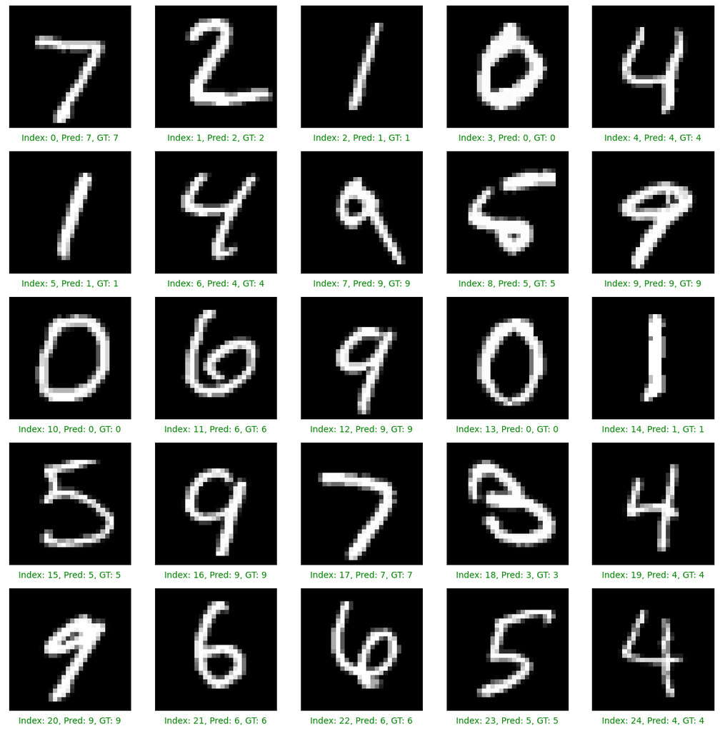

```python
import matplotlib.pyplot as plt
import numpy as np

plt.figure(figsize=(12, 12))
start_index = 0

for i in range(25):
    plt.subplot(5, 5, i + 1)
    plt.grid(False)
    plt.xticks([])
    plt.yticks([])

    # Show the image
    plt.imshow(x_test[start_index], cmap='gray')

    # Prediction
    pred = np.argmax(preds[start_index])
    gt = y_test[start_index]

    # Label color
    col = 'g' if pred == gt else 'r'

    # Label below the image
    plt.xlabel("Index: {}, Pred: {}, GT: {}".format(start_index, pred, gt), color=col)

    start_index += 1  # Move to next image

plt.tight_layout()
plt.show()
```

```python
!pip install ipycanvas
```

```
Downloading ipycanvas-0.13.3-py2.py3-none-any.whl (125 kB)
   ━━━━━━━━━━━━━━━━━━━━━━━━━━━━━━━━━━━━━━━━ 125.8/125.8 kB 38.2 MB/s eta 0:00:00
```

```python
!pip install opencv-python
```

[output not shown]

```python
import cv2
import numpy as np
from PIL import Image
import matplotlib.pyplot as plt
```

```python
import cv2
import matplotlib.pyplot as plt

img_path = r"C:\mnist_test\digit.jpeg"  # raw string avoids backslash issues

img = cv2.imread(img_path, cv2.IMREAD_GRAYSCALE)  # load in grayscale

if img is None:
    print("❌ Could not load image. Check path or file format.")
else:
    print("✅ Image loaded successfully!")
    plt.imshow(img, cmap='gray')
    plt.title("Your Digit")
    plt.axis('off')
    plt.show()
```

```
❌ Could not load image. Check path or file format.
```

```
[ WARN:0@1397.244] global loadsave.cpp:275 findDecoder imread_('C:\mnist_test\digit.jpeg'): can't open/read file: check file path/integrity
```

```python
if img is not None:
    print("Image loaded successfully!")
    plt.imshow(img, cmap='gray')
    plt.axis('off')
    plt.show()
else:
    print("❌ Image failed to load. Please check the file path.")
```

```
❌ Image failed to load. Please check the file path.
```